# Preliminary project Explanation:

In this project, I am processing a dataset on the number of **Hyundai** cars sold in the UK in recent years. I collected this dataset from the **Kaggle** website, which you can find in the zip file. Fortunately, this dataset does not need to be cleaned as the author has already done that, but I will first try to check the **missing, duplicate and NA values** and correct them in the preprossing part. This dataset contains three object columns (model, transmission, fuel type) that need to be coded before processing the whole dataset. I will try to do this using libraries and algorithms like **OneHotEncoder** and **LabelEncoder**. In this project, I encounter the question and problem of which features of this dataset have the most impact on car prices. So I will try to find the best feature that has a stronger correlation with the price.

Moreover, I would like to predict the price of the cars using the **ML algorithms** that we can use for this kind of dataset. Generally, price prediction datasets are classified as **supervised datasets**, so my project falls into this category. I will use **regression models** such as **Linier Regression, Desicion Tree and Randomforrest** in this project. I will split the dataset into a **training (70%) and test (30%) set**, scale the dataset using the **standard scaler** and **minmax scaler**, find the **Mean Squared Error (MSE), Root Mean Squared Error (RMSE), R2 value, and Cross-validation value**, and compare the models using these 4 error types by using statistic result and plots. Finally, after comparing the results of each model, I can propose the best model with the highest accuracy for predicting the price for this dataset.

I encounterd with some chalanges in my project such as finding some unusable values that could potentially destroy the integrity of the dataset and affect the results of the models. I also had to choose the best function for encoding the object columns between **LabelEncoder** and **OneHotEncoder**, In this case, I ran the project separately with both functions written to the project and compared both results and found that **OneHotEncoder** was better for encoding the object columns due to the number of models I have in the model columns (I wrote the LabelEncoder code as a comment in a chunk). Also, I had a same problem when I wanted to choose the better function for scaling the project. So, I ran the project with both the **standardscaler** and the MinMaxScaler and finally found that due to the large gap between min and max values in some columns, selecting the **MinMaxScaler** makes more sense for the project. Also, I tried to visualize the result of the model error by using some graphs to show the difference between the errors in each model, and I think this part of my project were the strong aspects of my analysis.

so my project objectives summarized to this three steps :

> To perform EDA to understand the underlying trends

> Clean the data and prepare it for regression models

> Fit different regression models and compare their performance at predicting the price of the cars

# Dataset

dataset is about the number of **Hyundai cars** sold in UK during the last yeras.The cleaned data set contains information of price, transmission, mileage, fuel type, road tax, miles per gallon (mpg), and engine size.inaddition contains **4860** rows that we encounter with them during the project.

> Model:model of car

> Year:the year that cars made

> Price:price of the car

> Transmission:type of gear

> Milage:how many miles the car went(1 mile = 1,609344 km)

> Fueltpe: fuel type

> Tax(£):tax

> Mpg :miles per galon (i galon = 3,78541178 liters)

> Enginsize: size of engin (liters)

# Importing the packages needed for the analysis

```python
import pandas as pd
import numpy as np
import matplotlib.pyplot as plt
import seaborn as sns

from pandas.plotting import scatter_matrix
from sklearn.preprocessing import StandardScaler, MinMaxScaler
from sklearn.preprocessing import OneHotEncoder
from sklearn.preprocessing import LabelEncoder
from sklearn.feature_selection import SelectKBest, f_regression
from sklearn.preprocessing import StandardScaler
from sklearn.model_selection import train_test_split, cross_val_score, LeaveOneOut
from sklearn import linear_model
from sklearn.linear_model import LinearRegression
from sklearn.preprocessing import PolynomialFeatures
from sklearn.tree import DecisionTreeRegressor
from sklearn.model_selection import validation_curve
from sklearn.metrics import mean_squared_error , r2_score ,accuracy_score
from sklearn.ensemble import RandomForestRegressor
plt.style.use('fivethirtyeight')
import warnings
warnings.filterwarnings('ignore')
```

# Preprocessing and Dataset Observation

First of all we start with reading the data set by using (pd.read_scv) to prepare the dataset for our project:

```python
cars = pd.read_csv("hyundi.csv", header = 0, sep =",")
```

As I said before, this data set is clear , but we should try to convince ourselves that the data set is completely clear, so let us try to find the possibility of null and duplicate values in our data set.

```python
cars.isnull().any()
```

```
model           False
year            False
price           False
transmission    False
mileage         False
fuelType        False
tax(£)          False
mpg             False
engineSize      False
dtype: bool
```

Good news ! after run the chunk above we find that the dataset does not contains any Null values.

Now try to find the duplicate values :

```python
cars = cars.drop_duplicates(keep='first').reset_index(drop=True)
cars.shape
```

```
(4774, 9)
```

Ooops, after run the chunk above we find that the dataset contains **86 duplicate values** which was dropped from the dataset immediately.

The info() function is used to print a concise summary of a DataFrame. This method prints information about a DataFrame including the index dtype and column dtypes, non-null values and memory usage which are important for us to use them in the project

```python
cars.info()
```

```
<class 'pandas.core.frame.DataFrame'>
RangeIndex: 4774 entries, 0 to 4773
Data columns (total 9 columns):
 #   Column        Non-Null Count  Dtype
---  ------        --------------  -----
 0   model         4774 non-null   object
 1   year          4774 non-null   int64
 2   price         4774 non-null   int64
 3   transmission  4774 non-null   object
 4   mileage       4774 non-null   int64
 5   fuelType      4774 non-null   object
 6   tax(£)        4774 non-null   int64
 7   mpg           4774 non-null   float64
 8   engineSize    4774 non-null   float64
dtypes: float64(2), int64(4), object(3)
memory usage: 335.8+ KB
```

Pandas head() method is used to return top n (5 by default) rows of a data frame

```python
cars.head()
```

|  | model | year | price | transmission | mileage | fuelType | tax(£) | mpg | engineSize |
| --- | --- | --- | --- | --- | --- | --- | --- | --- | --- |
| 0 | I20 | 2017 | 7999 | Manual | 17307 | Petrol | 145 | 58.9 | 1.2 |
| 1 | Tucson | 2016 | 14499 | Automatic | 25233 | Diesel | 235 | 43.5 | 2.0 |
| 2 | Tucson | 2016 | 11399 | Manual | 37877 | Diesel | 30 | 61.7 | 1.7 |
| 3 | I10 | 2016 | 6499 | Manual | 23789 | Petrol | 20 | 60.1 | 1.0 |
| 4 | IX35 | 2015 | 10199 | Manual | 33177 | Diesel | 160 | 51.4 | 2.0 |

Pandas tail() method is used to return last n (5 by default) rows of a data frame

```python
cars.tail()
```

|  | model | year | price | transmission | mileage | fuelType | tax(£) | mpg | engineSize |
| --- | --- | --- | --- | --- | --- | --- | --- | --- | --- |
| 4769 | I30 | 2016 | 8680 | Manual | 25906 | Diesel | 0 | 78.4 | 1.6 |
| 4770 | I40 | 2015 | 7830 | Manual | 59508 | Diesel | 30 | 65.7 | 1.7 |
| 4771 | I10 | 2017 | 6830 | Manual | 13810 | Petrol | 20 | 60.1 | 1.0 |
| 4772 | Tucson | 2018 | 13994 | Manual | 23313 | Petrol | 145 | 44.8 | 1.6 |
| 4773 | Tucson | 2016 | 15999 | Automatic | 11472 | Diesel | 125 | 57.6 | 1.7 |

In the next three columns below, we will try to find the unique elements and the number of unique elements in the three object columns ( model, transmission, and fuel type). in addition we provide a plot for each columns afterwards

```python
cars["model"].unique()
```

```
array([' I20', ' Tucson', ' I10', ' IX35', ' I30', ' I40', ' Ioniq',
       ' Kona', ' Veloster', ' I800', ' IX20', ' Santa Fe', ' Accent',
       ' Terracan', ' Getz', ' Amica'], dtype=object)
```

```python
cars["model"].value_counts()
```

```
 Tucson      1280
 I10         1061
 I30          535
 I20          487
 Kona         322
 Ioniq        275
 Santa Fe     244
 IX20         202
 I40          120
 IX35         118
 I800         117
 Getz           6
 Veloster       3
 Terracan       2
 Accent         1
 Amica          1
Name: model, dtype: int64
```

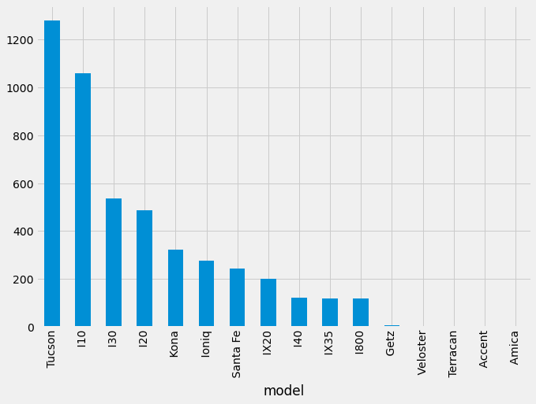

```python
plt.figure(figsize=(10, 7))
cars.value_counts(cars["model"]).plot.bar()
```

```python
cars["transmission"].unique()
```

```
array(['Manual', 'Automatic', 'Semi-Auto', 'Other'], dtype=object)
```

```python
cars["transmission"].value_counts()
```

```
Manual       3546
Automatic     658
Semi-Auto     568
Other           2
Name: transmission, dtype: int64
```

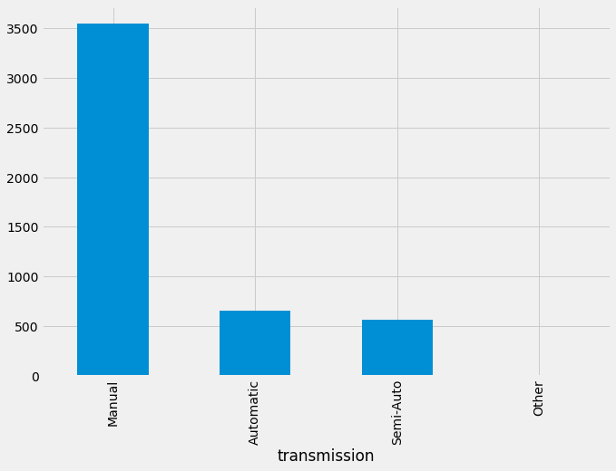

```python
plt.figure(figsize=(10, 7))
cars.value_counts(cars["transmission"]).plot.bar()
```

```python
cars["fuelType"].unique()
```

```
array(['Petrol', 'Diesel', 'Hybrid', 'Other'], dtype=object)
```

```python
cars["fuelType"].value_counts()
```

```
Petrol    2838
Diesel    1595
Hybrid     340
Other        1
Name: fuelType, dtype: int64
```

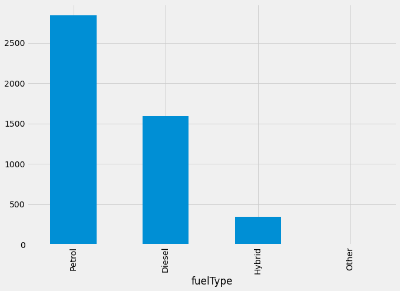

```python
plt.figure(figsize=(10, 7))
cars.value_counts(cars["fuelType"]).plot.bar()
```

The next two charts show the number of cars with different engine sizes and the number of cars sold in different years

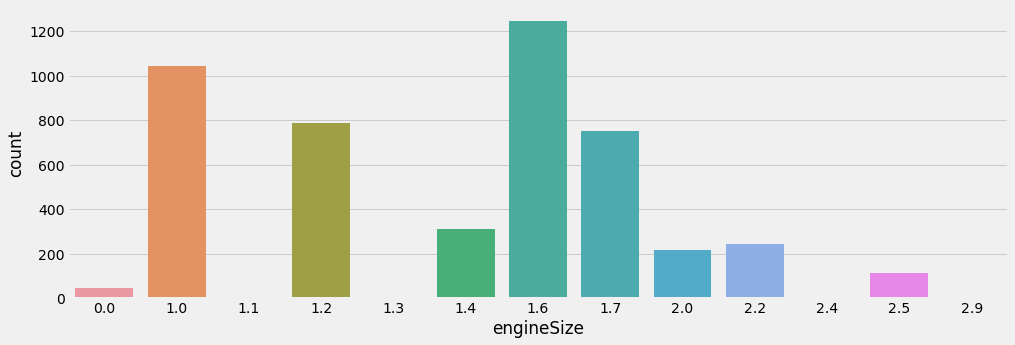

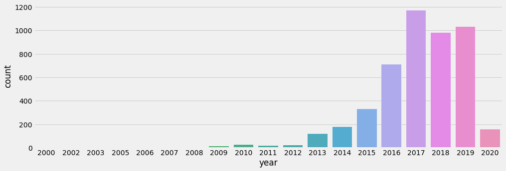

```python
list = [ 'engineSize', 'year']
for i in list:
    plt.figure(figsize=(15, 5))
    sns.countplot(cars[i])
    plt.show()
```

The **describe()** function computes a summary of statistics pertaining to the DataFrame columns. This function gives the mean, std and IQR values. And, function excludes the character columns and given summary about numeric columns.

```python
cars.describe()
```

|  | year | price | mileage | tax(£) | mpg | engineSize |
| --- | --- | --- | --- | --- | --- | --- |
| count | 4774.000000 | 4774.000000 | 4774.000000 | 4774.000000 | 4774.000000 | 4774.000000 |
| mean | 2017.092166 | 12727.809384 | 21658.914537 | 121.187683 | 53.837956 | 1.460285 |
| std | 1.921323 | 5976.925227 | 17618.489657 | 58.135472 | 12.740499 | 0.401858 |
| min | 2000.000000 | 1200.000000 | 1.000000 | 0.000000 | 1.100000 | 0.000000 |
| 25% | 2016.000000 | 8000.000000 | 8542.500000 | 125.000000 | 44.800000 | 1.200000 |
| 50% | 2017.000000 | 11992.500000 | 17627.000000 | 145.000000 | 55.400000 | 1.600000 |
| 75% | 2018.000000 | 15695.000000 | 31067.500000 | 145.000000 | 60.100000 | 1.700000 |
| max | 2020.000000 | 92000.000000 | 138000.000000 | 555.000000 | 256.800000 | 2.900000 |

Create histograms to display the values of the numerical columns

```
array([[<AxesSubplot:title={'center':'year'}>,
        <AxesSubplot:title={'center':'price'}>],
       [<AxesSubplot:title={'center':'mileage'}>,
        <AxesSubplot:title={'center':'tax(£)'}>],
       [<AxesSubplot:title={'center':'mpg'}>,
        <AxesSubplot:title={'center':'engineSize'}>]], dtype=object)
```

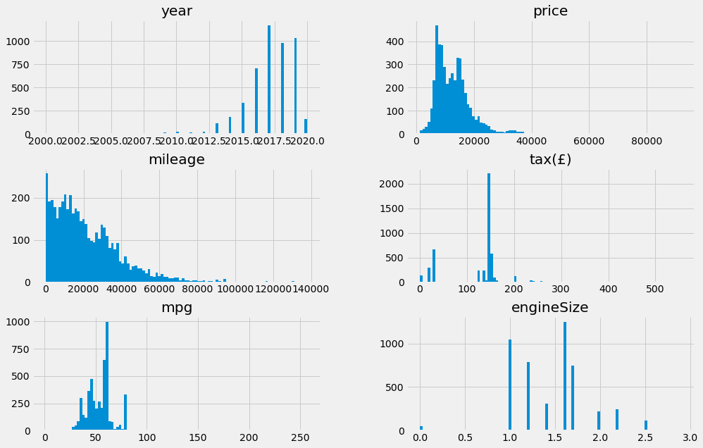

```python
cars.hist(bins = 100, figsize = (15,10))
```

Change of name from tax(£) to tax due to simplify use it in the project.

```python
cars.rename(columns= {'tax(£)': 'tax'}, inplace = True)
cars_edit = cars.copy()
cars_edit
```

|  | model | year | price | transmission | mileage | fuelType | tax | mpg | engineSize |
| --- | --- | --- | --- | --- | --- | --- | --- | --- | --- |
| 0 | I20 | 2017 | 7999 | Manual | 17307 | Petrol | 145 | 58.9 | 1.2 |
| 1 | Tucson | 2016 | 14499 | Automatic | 25233 | Diesel | 235 | 43.5 | 2.0 |
| 2 | Tucson | 2016 | 11399 | Manual | 37877 | Diesel | 30 | 61.7 | 1.7 |
| 3 | I10 | 2016 | 6499 | Manual | 23789 | Petrol | 20 | 60.1 | 1.0 |
| 4 | IX35 | 2015 | 10199 | Manual | 33177 | Diesel | 160 | 51.4 | 2.0 |
| ... | ... | ... | ... | ... | ... | ... | ... | ... | ... |
| 4769 | I30 | 2016 | 8680 | Manual | 25906 | Diesel | 0 | 78.4 | 1.6 |
| 4770 | I40 | 2015 | 7830 | Manual | 59508 | Diesel | 30 | 65.7 | 1.7 |
| 4771 | I10 | 2017 | 6830 | Manual | 13810 | Petrol | 20 | 60.1 | 1.0 |
| 4772 | Tucson | 2018 | 13994 | Manual | 23313 | Petrol | 145 | 44.8 | 1.6 |
| 4773 | Tucson | 2016 | 15999 | Automatic | 11472 | Diesel | 125 | 57.6 | 1.7 |

4774 rows × 9 columns

During the initial observation of the dataset, I found the following line referring to the Hyundei model I10, but its price is about 10 times higher than the average price of this model according to the whole dataset, so I determined that this price is not real and replaced it with the rational price to maintain the integrity of the dataset

```python
cars[cars["price"] == 92000]
```

|  | model | year | price | transmission | mileage | fuelType | tax | mpg | engineSize |
| --- | --- | --- | --- | --- | --- | --- | --- | --- | --- |
| 4165 | I10 | 2017 | 92000 | Automatic | 35460 | Petrol | 150 | 47.9 | 1.2 |

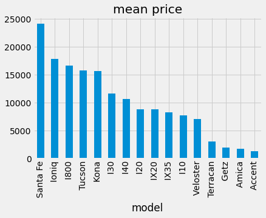

```python
# we can see that there is a maximum value which is compeletly different with other values
# i checked it and found this value is a human mistake when they wanted to fill the dataset
# this value equals 92000 which i consider it as 9200 in my data to Maintain the dataset's integrity
model = cars_edit.groupby(['model']).mean()['price'].sort_values(ascending=False)
model.plot(kind='bar',title = 'mean price')
cars_edit.loc[cars_edit.price > 80000, 'price']= 9200
```

Now we would like to determine the correlation of the numeric columns with the price column to get a better insight into these columns: We use a scatter plot to show these correlations

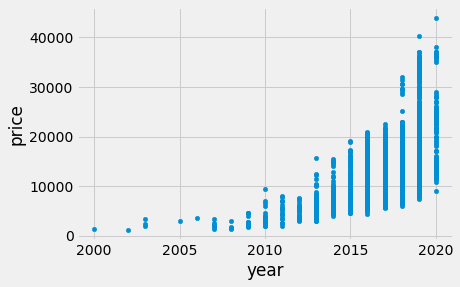

```python
cars_edit.plot.scatter(x = "year", y = "price")
```

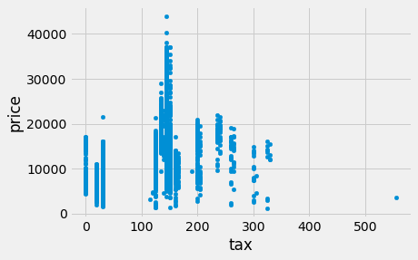

```python
cars_edit.plot.scatter(x = "tax", y = "price")
```

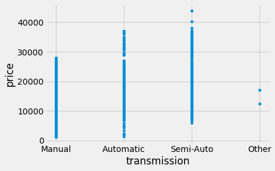

```python
cars_edit.plot.scatter(x = "transmission", y = "price")
```

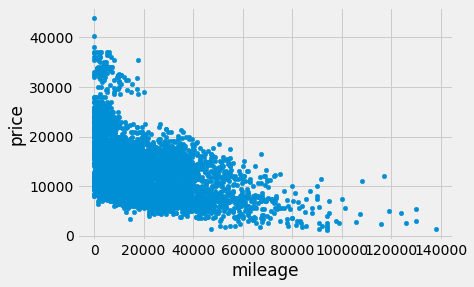

```python
cars_edit.plot.scatter(x = "mileage", y = "price")
```

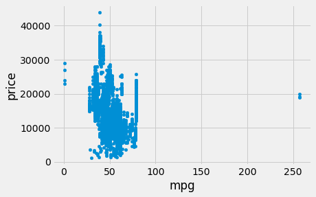

```python
cars_edit.plot.scatter(x = "mpg", y = "price")
```

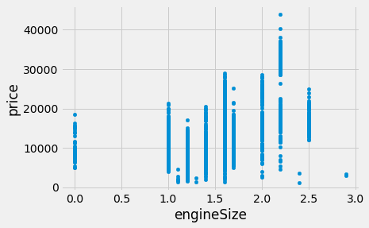

```python
cars_edit.plot.scatter(x = "engineSize", y = "price")
```

This is a figure-level function for visualizing statistical relationships between columns to find the rational relationship between them

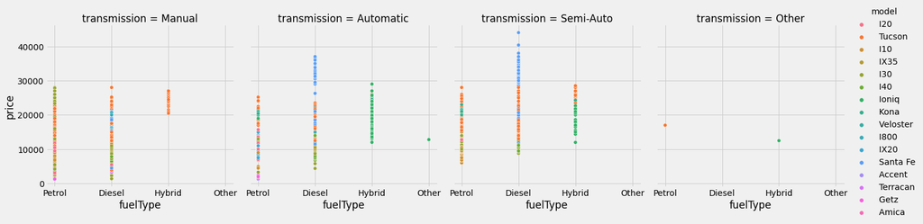

```python
sns.relplot(data=cars_edit, x="fuelType", y="price", hue="model",col ="transmission" )
```

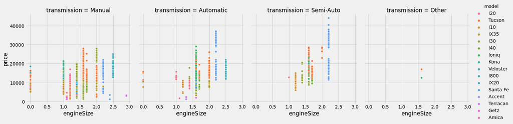

```python
sns.relplot(data=cars_edit, x="engineSize", y="price", hue="model",col ="transmission" )
```

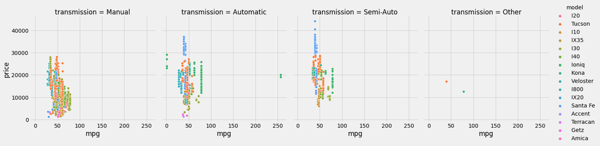

```python
sns.relplot(data=cars_edit, x="mpg", y="price", hue="model",col ="transmission" )
```

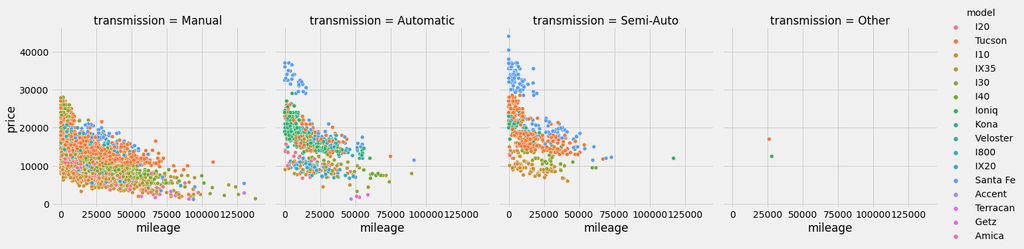

```python
sns.relplot(data=cars_edit, x="mileage", y="price", hue="model",col ="transmission" )
```

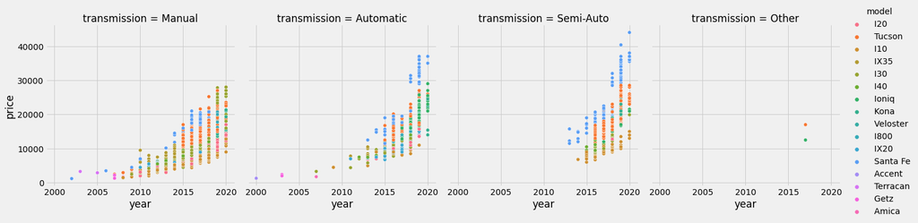

```python
sns.relplot(data=cars_edit, x="year", y="price", hue="model",col ="transmission" )
```

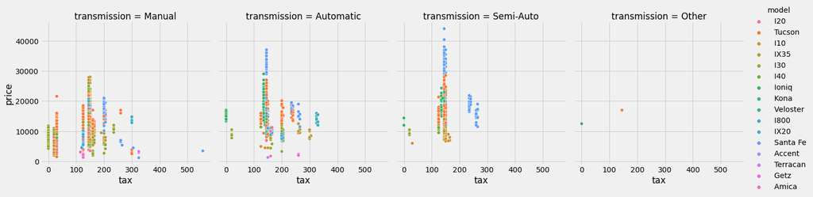

```python
sns.relplot(data=cars_edit, x="tax", y="price", hue="model",col ="transmission" )
```

```python
cars.corr()["price"].sort_values()
```

```
mileage      -0.443754
mpg          -0.323742
tax           0.318448
engineSize    0.521832
year          0.575325
price         1.000000
Name: price, dtype: float64
```

Now we use a heat map plot to show the correlations between the columns and find out which columns are more strongly correlated with price.

From this heatmap, we see that year, engine, and tax have a stronger positive correlation with price, while mileage and mileage have a negative correlation with the price column.

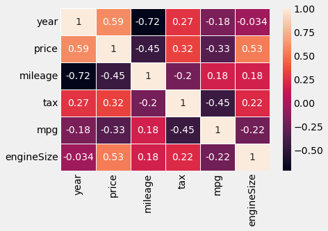

```python
sns.heatmap(cars_edit.corr(), annot=True, linewidths=1)
```

this is a grid of scatter plots to visualize bivariate relationships between combinations of variables. Each scatter plot in the matrix visualizes the relationship between a pair of variables, allowing many relationships to be explored in one chart.

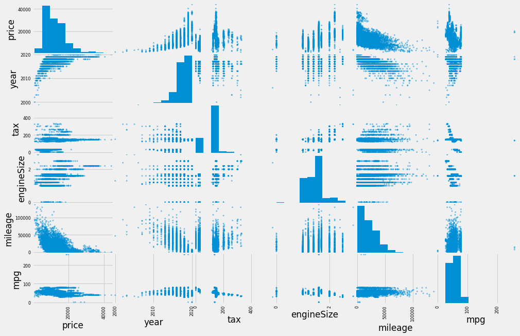

```python
features = ["price","year","tax","engineSize","mileage","mpg"]
scatter_matrix(cars_edit[features], figsize = (15,10))
plt.show()
```

# Summary of Dataset observation and visualization

**We can mention to some below point as a summary of our Dataset observation and relation and corrolation between the columns:**

> The more the year increases, the more car prices increase. From this we can easily conclude that the year has a positive correlation with the price tag, which we can find in the previous heatmap .

> Most cars in the data use a manual transmission, the price of which is below 30000. Also, cars with a semi-automatic transmission are more expensive than other models. Also, most cars in this dataset have engines with displacement between 1 and 2.5 liters.

> According to this data, most of the cars have driven less than 75000 miles and the cars with manual transmission have driven the most. Also, the cars with the high price tag have driven less than other cars.

# preparing Data for regression models

**After cleaning and exploration data analysis, the next step is to prepare the data for input into a regression model.**

> First, we divide the data set into two parts (numeric data and categorical data).

> We need to convert all categorical variables into numerical values by **OnehotEncoder** or **LabelEncoder**. We also need to standardize the predictors with **standardScaler** or **MinMaxScaler**, which is essential for regularized regression.

> Finally, we merge both data back together. Now we have a suitable data set to use in the next steps.

```python
df = cars_edit.copy()
df_num = df.drop(["model","transmission","fuelType"], axis = 1 )
df_num
```

|  | year | price | mileage | tax | mpg | engineSize |
| --- | --- | --- | --- | --- | --- | --- |
| 0 | 2017 | 7999 | 17307 | 145 | 58.9 | 1.2 |
| 1 | 2016 | 14499 | 25233 | 235 | 43.5 | 2.0 |
| 2 | 2016 | 11399 | 37877 | 30 | 61.7 | 1.7 |
| 3 | 2016 | 6499 | 23789 | 20 | 60.1 | 1.0 |
| 4 | 2015 | 10199 | 33177 | 160 | 51.4 | 2.0 |
| ... | ... | ... | ... | ... | ... | ... |
| 4769 | 2016 | 8680 | 25906 | 0 | 78.4 | 1.6 |
| 4770 | 2015 | 7830 | 59508 | 30 | 65.7 | 1.7 |
| 4771 | 2017 | 6830 | 13810 | 20 | 60.1 | 1.0 |
| 4772 | 2018 | 13994 | 23313 | 145 | 44.8 | 1.6 |
| 4773 | 2016 | 15999 | 11472 | 125 | 57.6 | 1.7 |

4774 rows × 6 columns

```python
df_num.describe()
```

|  | year | price | mileage | tax | mpg | engineSize |
| --- | --- | --- | --- | --- | --- | --- |
| count | 4774.000000 | 4774.000000 | 4774.000000 | 4774.000000 | 4774.000000 | 4774.000000 |
| mean | 2017.092166 | 12710.465438 | 21658.914537 | 121.187683 | 53.837956 | 1.460285 |
| std | 1.921323 | 5865.948565 | 17618.489657 | 58.135472 | 12.740499 | 0.401858 |
| min | 2000.000000 | 1200.000000 | 1.000000 | 0.000000 | 1.100000 | 0.000000 |
| 25% | 2016.000000 | 8000.000000 | 8542.500000 | 125.000000 | 44.800000 | 1.200000 |
| 50% | 2017.000000 | 11990.500000 | 17627.000000 | 145.000000 | 55.400000 | 1.600000 |
| 75% | 2018.000000 | 15694.250000 | 31067.500000 | 145.000000 | 60.100000 | 1.700000 |
| max | 2020.000000 | 43995.000000 | 138000.000000 | 555.000000 | 256.800000 | 2.900000 |

in this section, we can use both the LabelEncoder() and OneHotEncoder() functions to convert all categorical variables to numeric values.

I have written both encoder functions below, but due to the large number of models (16 models), I prefer OneHotEncoder to encode the categorical columns.

```python
#encoder = LabelEncoder()
#df["model"] = encoder.fit_transform(df["model"])
#df["transmission"] = encoder.fit_transform(df["transmission"])
#df["fuelType"] = encoder.fit_transform(df["fuelType"])
#df_clean = df.copy()
```

```python
df_onehot = OneHotEncoder(sparse= False)
df_onehot_encoded = df_onehot.fit_transform(df[["model","transmission","fuelType"]])
column_name = df_onehot.get_feature_names(["model","transmission","fuelType"])
df_onehot_final = pd.DataFrame(df_onehot_encoded, columns= column_name)
df_onehot_final.head()
```

|  | model_ Accent | model_ Amica | model_ Getz | model_ I10 | model_ I20 | model_ I30 | model_ I40 | model_ I800 | model_ IX20 | model_ IX35 | ... | model_ Tucson | model_ Veloster | transmission_Automatic | transmission_Manual | transmission_Other | transmission_Semi-Auto | fuelType_Diesel | fuelType_Hybrid | fuelType_Other | fuelType_Petrol |
| --- | --- | --- | --- | --- | --- | --- | --- | --- | --- | --- | --- | --- | --- | --- | --- | --- | --- | --- | --- | --- | --- |
| 0 | 0.0 | 0.0 | 0.0 | 0.0 | 1.0 | 0.0 | 0.0 | 0.0 | 0.0 | 0.0 | ... | 0.0 | 0.0 | 0.0 | 1.0 | 0.0 | 0.0 | 0.0 | 0.0 | 0.0 | 1.0 |
| 1 | 0.0 | 0.0 | 0.0 | 0.0 | 0.0 | 0.0 | 0.0 | 0.0 | 0.0 | 0.0 | ... | 1.0 | 0.0 | 1.0 | 0.0 | 0.0 | 0.0 | 1.0 | 0.0 | 0.0 | 0.0 |
| 2 | 0.0 | 0.0 | 0.0 | 0.0 | 0.0 | 0.0 | 0.0 | 0.0 | 0.0 | 0.0 | ... | 1.0 | 0.0 | 0.0 | 1.0 | 0.0 | 0.0 | 1.0 | 0.0 | 0.0 | 0.0 |
| 3 | 0.0 | 0.0 | 0.0 | 1.0 | 0.0 | 0.0 | 0.0 | 0.0 | 0.0 | 0.0 | ... | 0.0 | 0.0 | 0.0 | 1.0 | 0.0 | 0.0 | 0.0 | 0.0 | 0.0 | 1.0 |
| 4 | 0.0 | 0.0 | 0.0 | 0.0 | 0.0 | 0.0 | 0.0 | 0.0 | 0.0 | 1.0 | ... | 0.0 | 0.0 | 0.0 | 1.0 | 0.0 | 0.0 | 1.0 | 0.0 | 0.0 | 0.0 |

5 rows × 24 columns

We can do this by using pd.get_dummies(). This function encodes the labels just as OneHotEncoder does.

> df_dummies= pd.get_dummies(df)

Now we merge two data into one clean data:

```python
df_clean = pd.concat([df_num,df_onehot_final], axis=1)
df_clean
```

|  | year | price | mileage | tax | mpg | engineSize | model_ Accent | model_ Amica | model_ Getz | model_ I10 | ... | model_ Tucson | model_ Veloster | transmission_Automatic | transmission_Manual | transmission_Other | transmission_Semi-Auto | fuelType_Diesel | fuelType_Hybrid | fuelType_Other | fuelType_Petrol |
| --- | --- | --- | --- | --- | --- | --- | --- | --- | --- | --- | --- | --- | --- | --- | --- | --- | --- | --- | --- | --- | --- |
| 0 | 2017 | 7999 | 17307 | 145 | 58.9 | 1.2 | 0.0 | 0.0 | 0.0 | 0.0 | ... | 0.0 | 0.0 | 0.0 | 1.0 | 0.0 | 0.0 | 0.0 | 0.0 | 0.0 | 1.0 |
| 1 | 2016 | 14499 | 25233 | 235 | 43.5 | 2.0 | 0.0 | 0.0 | 0.0 | 0.0 | ... | 1.0 | 0.0 | 1.0 | 0.0 | 0.0 | 0.0 | 1.0 | 0.0 | 0.0 | 0.0 |
| 2 | 2016 | 11399 | 37877 | 30 | 61.7 | 1.7 | 0.0 | 0.0 | 0.0 | 0.0 | ... | 1.0 | 0.0 | 0.0 | 1.0 | 0.0 | 0.0 | 1.0 | 0.0 | 0.0 | 0.0 |
| 3 | 2016 | 6499 | 23789 | 20 | 60.1 | 1.0 | 0.0 | 0.0 | 0.0 | 1.0 | ... | 0.0 | 0.0 | 0.0 | 1.0 | 0.0 | 0.0 | 0.0 | 0.0 | 0.0 | 1.0 |
| 4 | 2015 | 10199 | 33177 | 160 | 51.4 | 2.0 | 0.0 | 0.0 | 0.0 | 0.0 | ... | 0.0 | 0.0 | 0.0 | 1.0 | 0.0 | 0.0 | 1.0 | 0.0 | 0.0 | 0.0 |
| ... | ... | ... | ... | ... | ... | ... | ... | ... | ... | ... | ... | ... | ... | ... | ... | ... | ... | ... | ... | ... | ... |
| 4769 | 2016 | 8680 | 25906 | 0 | 78.4 | 1.6 | 0.0 | 0.0 | 0.0 | 0.0 | ... | 0.0 | 0.0 | 0.0 | 1.0 | 0.0 | 0.0 | 1.0 | 0.0 | 0.0 | 0.0 |
| 4770 | 2015 | 7830 | 59508 | 30 | 65.7 | 1.7 | 0.0 | 0.0 | 0.0 | 0.0 | ... | 0.0 | 0.0 | 0.0 | 1.0 | 0.0 | 0.0 | 1.0 | 0.0 | 0.0 | 0.0 |
| 4771 | 2017 | 6830 | 13810 | 20 | 60.1 | 1.0 | 0.0 | 0.0 | 0.0 | 1.0 | ... | 0.0 | 0.0 | 0.0 | 1.0 | 0.0 | 0.0 | 0.0 | 0.0 | 0.0 | 1.0 |
| 4772 | 2018 | 13994 | 23313 | 145 | 44.8 | 1.6 | 0.0 | 0.0 | 0.0 | 0.0 | ... | 1.0 | 0.0 | 0.0 | 1.0 | 0.0 | 0.0 | 0.0 | 0.0 | 0.0 | 1.0 |
| 4773 | 2016 | 15999 | 11472 | 125 | 57.6 | 1.7 | 0.0 | 0.0 | 0.0 | 0.0 | ... | 1.0 | 0.0 | 1.0 | 0.0 | 0.0 | 0.0 | 1.0 | 0.0 | 0.0 | 0.0 |

4774 rows × 30 columns

```python
df_clean.describe()
```

|  | year | price | mileage | tax | mpg | engineSize | model_ Accent | model_ Amica | model_ Getz | model_ I10 | ... | model_ Tucson | model_ Veloster | transmission_Automatic | transmission_Manual | transmission_Other | transmission_Semi-Auto | fuelType_Diesel | fuelType_Hybrid | fuelType_Other | fuelType_Petrol |
| --- | --- | --- | --- | --- | --- | --- | --- | --- | --- | --- | --- | --- | --- | --- | --- | --- | --- | --- | --- | --- | --- |
| count | 4774.000000 | 4774.000000 | 4774.000000 | 4774.000000 | 4774.000000 | 4774.000000 | 4774.000000 | 4774.000000 | 4774.000000 | 4774.000000 | ... | 4774.000000 | 4774.000000 | 4774.000000 | 4774.000000 | 4774.000000 | 4774.000000 | 4774.000000 | 4774.000000 | 4774.000000 | 4774.000000 |
| mean | 2017.092166 | 12710.465438 | 21658.914537 | 121.187683 | 53.837956 | 1.460285 | 0.000209 | 0.000209 | 0.001257 | 0.222245 | ... | 0.268119 | 0.000628 | 0.137830 | 0.742773 | 0.000419 | 0.118978 | 0.334101 | 0.071219 | 0.000209 | 0.594470 |
| std | 1.921323 | 5865.948565 | 17618.489657 | 58.135472 | 12.740499 | 0.401858 | 0.014473 | 0.014473 | 0.035433 | 0.415799 | ... | 0.443026 | 0.025063 | 0.344757 | 0.437151 | 0.020466 | 0.323796 | 0.471725 | 0.257217 | 0.014473 | 0.491046 |
| min | 2000.000000 | 1200.000000 | 1.000000 | 0.000000 | 1.100000 | 0.000000 | 0.000000 | 0.000000 | 0.000000 | 0.000000 | ... | 0.000000 | 0.000000 | 0.000000 | 0.000000 | 0.000000 | 0.000000 | 0.000000 | 0.000000 | 0.000000 | 0.000000 |
| 25% | 2016.000000 | 8000.000000 | 8542.500000 | 125.000000 | 44.800000 | 1.200000 | 0.000000 | 0.000000 | 0.000000 | 0.000000 | ... | 0.000000 | 0.000000 | 0.000000 | 0.000000 | 0.000000 | 0.000000 | 0.000000 | 0.000000 | 0.000000 | 0.000000 |
| 50% | 2017.000000 | 11990.500000 | 17627.000000 | 145.000000 | 55.400000 | 1.600000 | 0.000000 | 0.000000 | 0.000000 | 0.000000 | ... | 0.000000 | 0.000000 | 0.000000 | 1.000000 | 0.000000 | 0.000000 | 0.000000 | 0.000000 | 0.000000 | 1.000000 |
| 75% | 2018.000000 | 15694.250000 | 31067.500000 | 145.000000 | 60.100000 | 1.700000 | 0.000000 | 0.000000 | 0.000000 | 0.000000 | ... | 1.000000 | 0.000000 | 0.000000 | 1.000000 | 0.000000 | 0.000000 | 1.000000 | 0.000000 | 0.000000 | 1.000000 |
| max | 2020.000000 | 43995.000000 | 138000.000000 | 555.000000 | 256.800000 | 2.900000 | 1.000000 | 1.000000 | 1.000000 | 1.000000 | ... | 1.000000 | 1.000000 | 1.000000 | 1.000000 | 1.000000 | 1.000000 | 1.000000 | 1.000000 | 1.000000 | 1.000000 |

8 rows × 30 columns

**For scaling the dataset as the last step, we have two scaling functions (StandardScaler and MinMaxScaler). I have incorporated both functions into the scaling of the dataset.**

> After the previous description, I noticed that the distance between the minimum and maximum values in some columns is larger than usual. Therefore, I decided to scale the data set with MinMaxScaler. As you can see, after scaling the data with MinMaxScaler, our variables are in the range between 0 and 1.

```python
#scaler = StandardScaler()
scaler = MinMaxScaler()

data_scaled = scaler.fit_transform(df_clean)
data_scaled = pd.DataFrame(data_scaled, columns=df_clean.columns)


df_cars = data_scaled.copy()
df_cars
```

|  | year | price | mileage | tax | mpg | engineSize | model_ Accent | model_ Amica | model_ Getz | model_ I10 | ... | model_ Tucson | model_ Veloster | transmission_Automatic | transmission_Manual | transmission_Other | transmission_Semi-Auto | fuelType_Diesel | fuelType_Hybrid | fuelType_Other | fuelType_Petrol |
| --- | --- | --- | --- | --- | --- | --- | --- | --- | --- | --- | --- | --- | --- | --- | --- | --- | --- | --- | --- | --- | --- |
| 0 | 0.85 | 0.158874 | 0.125407 | 0.261261 | 0.226046 | 0.413793 | 0.0 | 0.0 | 0.0 | 0.0 | ... | 0.0 | 0.0 | 0.0 | 1.0 | 0.0 | 0.0 | 0.0 | 0.0 | 0.0 | 1.0 |
| 1 | 0.80 | 0.310761 | 0.182842 | 0.423423 | 0.165819 | 0.689655 | 0.0 | 0.0 | 0.0 | 0.0 | ... | 1.0 | 0.0 | 1.0 | 0.0 | 0.0 | 0.0 | 1.0 | 0.0 | 0.0 | 0.0 |
| 2 | 0.80 | 0.238322 | 0.274466 | 0.054054 | 0.236996 | 0.586207 | 0.0 | 0.0 | 0.0 | 0.0 | ... | 1.0 | 0.0 | 0.0 | 1.0 | 0.0 | 0.0 | 1.0 | 0.0 | 0.0 | 0.0 |
| 3 | 0.80 | 0.123823 | 0.172378 | 0.036036 | 0.230739 | 0.344828 | 0.0 | 0.0 | 0.0 | 1.0 | ... | 0.0 | 0.0 | 0.0 | 1.0 | 0.0 | 0.0 | 0.0 | 0.0 | 0.0 | 1.0 |
| 4 | 0.75 | 0.210282 | 0.240408 | 0.288288 | 0.196715 | 0.689655 | 0.0 | 0.0 | 0.0 | 0.0 | ... | 0.0 | 0.0 | 0.0 | 1.0 | 0.0 | 0.0 | 1.0 | 0.0 | 0.0 | 0.0 |
| ... | ... | ... | ... | ... | ... | ... | ... | ... | ... | ... | ... | ... | ... | ... | ... | ... | ... | ... | ... | ... | ... |
| 4769 | 0.80 | 0.174787 | 0.187719 | 0.000000 | 0.302307 | 0.551724 | 0.0 | 0.0 | 0.0 | 0.0 | ... | 0.0 | 0.0 | 0.0 | 1.0 | 0.0 | 0.0 | 1.0 | 0.0 | 0.0 | 0.0 |
| 4770 | 0.75 | 0.154925 | 0.431213 | 0.054054 | 0.252640 | 0.586207 | 0.0 | 0.0 | 0.0 | 0.0 | ... | 0.0 | 0.0 | 0.0 | 1.0 | 0.0 | 0.0 | 1.0 | 0.0 | 0.0 | 0.0 |
| 4771 | 0.85 | 0.131557 | 0.100066 | 0.036036 | 0.230739 | 0.344828 | 0.0 | 0.0 | 0.0 | 1.0 | ... | 0.0 | 0.0 | 0.0 | 1.0 | 0.0 | 0.0 | 0.0 | 0.0 | 0.0 | 1.0 |
| 4772 | 0.90 | 0.298960 | 0.168929 | 0.261261 | 0.170903 | 0.551724 | 0.0 | 0.0 | 0.0 | 0.0 | ... | 1.0 | 0.0 | 0.0 | 1.0 | 0.0 | 0.0 | 0.0 | 0.0 | 0.0 | 1.0 |
| 4773 | 0.80 | 0.345811 | 0.083124 | 0.225225 | 0.220962 | 0.586207 | 0.0 | 0.0 | 0.0 | 0.0 | ... | 1.0 | 0.0 | 1.0 | 0.0 | 0.0 | 0.0 | 1.0 | 0.0 | 0.0 | 0.0 |

4774 rows × 30 columns

```python
df_cars.describe()
```

|  | year | price | mileage | tax | mpg | engineSize | model_ Accent | model_ Amica | model_ Getz | model_ I10 | ... | model_ Tucson | model_ Veloster | transmission_Automatic | transmission_Manual | transmission_Other | transmission_Semi-Auto | fuelType_Diesel | fuelType_Hybrid | fuelType_Other | fuelType_Petrol |
| --- | --- | --- | --- | --- | --- | --- | --- | --- | --- | --- | --- | --- | --- | --- | --- | --- | --- | --- | --- | --- | --- |
| count | 4774.000000 | 4774.000000 | 4774.000000 | 4774.000000 | 4774.000000 | 4774.000000 | 4774.000000 | 4774.000000 | 4774.000000 | 4774.000000 | ... | 4774.000000 | 4774.000000 | 4774.000000 | 4774.000000 | 4774.000000 | 4774.000000 | 4774.000000 | 4774.000000 | 4774.000000 | 4774.000000 |
| mean | 0.854608 | 0.268968 | 0.156943 | 0.218356 | 0.206249 | 0.503547 | 0.000209 | 0.000209 | 0.001257 | 0.222245 | ... | 0.268119 | 0.000628 | 0.137830 | 0.742773 | 0.000419 | 0.118978 | 0.334101 | 0.071219 | 0.000209 | 0.594470 |
| std | 0.096066 | 0.137071 | 0.127671 | 0.104749 | 0.049826 | 0.138572 | 0.014473 | 0.014473 | 0.035433 | 0.415799 | ... | 0.443026 | 0.025063 | 0.344757 | 0.437151 | 0.020466 | 0.323796 | 0.471725 | 0.257217 | 0.014473 | 0.491046 |
| min | 0.000000 | 0.000000 | 0.000000 | 0.000000 | 0.000000 | 0.000000 | 0.000000 | 0.000000 | 0.000000 | 0.000000 | ... | 0.000000 | 0.000000 | 0.000000 | 0.000000 | 0.000000 | 0.000000 | 0.000000 | 0.000000 | 0.000000 | 0.000000 |
| 25% | 0.800000 | 0.158897 | 0.061895 | 0.225225 | 0.170903 | 0.413793 | 0.000000 | 0.000000 | 0.000000 | 0.000000 | ... | 0.000000 | 0.000000 | 0.000000 | 0.000000 | 0.000000 | 0.000000 | 0.000000 | 0.000000 | 0.000000 | 0.000000 |
| 50% | 0.850000 | 0.252144 | 0.127726 | 0.261261 | 0.212358 | 0.551724 | 0.000000 | 0.000000 | 0.000000 | 0.000000 | ... | 0.000000 | 0.000000 | 0.000000 | 1.000000 | 0.000000 | 0.000000 | 0.000000 | 0.000000 | 0.000000 | 1.000000 |
| 75% | 0.900000 | 0.338690 | 0.225121 | 0.261261 | 0.230739 | 0.586207 | 0.000000 | 0.000000 | 0.000000 | 0.000000 | ... | 1.000000 | 0.000000 | 0.000000 | 1.000000 | 0.000000 | 0.000000 | 1.000000 | 0.000000 | 0.000000 | 1.000000 |
| max | 1.000000 | 1.000000 | 1.000000 | 1.000000 | 1.000000 | 1.000000 | 1.000000 | 1.000000 | 1.000000 | 1.000000 | ... | 1.000000 | 1.000000 | 1.000000 | 1.000000 | 1.000000 | 1.000000 | 1.000000 | 1.000000 | 1.000000 | 1.000000 |

8 rows × 30 columns

**This is a correlation heatmap showing the correlations between all columns after coding and scaling the data. In the next steps, I will show which columns are more strongly correlated with price.**

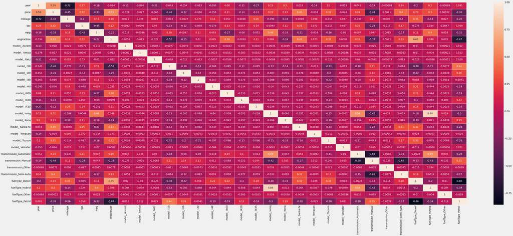

```python
sns.heatmap(df_cars.corr(), annot=True, linewidths=1)
```

select the X and Y to use them in the next steps

```python
x = df_cars.drop(columns= 'price')
y= df_cars.price
```

According to the previous heatmap, we noticed that after coding the data, some new columns have a relationship with the price that we did not know in the first heatmap. With the following code we can find out which columns have a stronger connection with the price

```python
k=4
selector = SelectKBest(f_regression,k=k)
selector.fit(x,y)
best_feats = selector.get_support(indices=True)
x_best =x.iloc[:,best_feats]
x_best.head()
```

|  | year | engineSize | model_ I10 | transmission_Manual |
| --- | --- | --- | --- | --- |
| 0 | 0.85 | 0.413793 | 0.0 | 1.0 |
| 1 | 0.80 | 0.689655 | 0.0 | 0.0 |
| 2 | 0.80 | 0.586207 | 0.0 | 1.0 |
| 3 | 0.80 | 0.344828 | 1.0 | 1.0 |
| 4 | 0.75 | 0.689655 | 0.0 | 1.0 |

```python
y.head()
```

```
0    0.158874
1    0.310761
2    0.238322
3    0.123823
4    0.210282
Name: price, dtype: float64
```

```python
x.head()
```

|  | year | mileage | tax | mpg | engineSize | model_ Accent | model_ Amica | model_ Getz | model_ I10 | model_ I20 | ... | model_ Tucson | model_ Veloster | transmission_Automatic | transmission_Manual | transmission_Other | transmission_Semi-Auto | fuelType_Diesel | fuelType_Hybrid | fuelType_Other | fuelType_Petrol |
| --- | --- | --- | --- | --- | --- | --- | --- | --- | --- | --- | --- | --- | --- | --- | --- | --- | --- | --- | --- | --- | --- |
| 0 | 0.85 | 0.125407 | 0.261261 | 0.226046 | 0.413793 | 0.0 | 0.0 | 0.0 | 0.0 | 1.0 | ... | 0.0 | 0.0 | 0.0 | 1.0 | 0.0 | 0.0 | 0.0 | 0.0 | 0.0 | 1.0 |
| 1 | 0.80 | 0.182842 | 0.423423 | 0.165819 | 0.689655 | 0.0 | 0.0 | 0.0 | 0.0 | 0.0 | ... | 1.0 | 0.0 | 1.0 | 0.0 | 0.0 | 0.0 | 1.0 | 0.0 | 0.0 | 0.0 |
| 2 | 0.80 | 0.274466 | 0.054054 | 0.236996 | 0.586207 | 0.0 | 0.0 | 0.0 | 0.0 | 0.0 | ... | 1.0 | 0.0 | 0.0 | 1.0 | 0.0 | 0.0 | 1.0 | 0.0 | 0.0 | 0.0 |
| 3 | 0.80 | 0.172378 | 0.036036 | 0.230739 | 0.344828 | 0.0 | 0.0 | 0.0 | 1.0 | 0.0 | ... | 0.0 | 0.0 | 0.0 | 1.0 | 0.0 | 0.0 | 0.0 | 0.0 | 0.0 | 1.0 |
| 4 | 0.75 | 0.240408 | 0.288288 | 0.196715 | 0.689655 | 0.0 | 0.0 | 0.0 | 0.0 | 0.0 | ... | 0.0 | 0.0 | 0.0 | 1.0 | 0.0 | 0.0 | 1.0 | 0.0 | 0.0 | 0.0 |

5 rows × 29 columns

finally, we split our data set into train set and test set at the final step of this part.

> Train/Test is a method to measure the accuracy of your model.so we split the the data set into two sets: a training set and a testing set. 70% for training, and 30% for testing.with train set we will train the model then we will test our model with the test values.

> Random state consider as 42 in this project

```python
x_train, x_test, y_train, y_test = train_test_split(x, y, test_size=0.3, random_state=42)
print(x_train.shape)
print(x_test.shape)
print(y_train.shape)
print(y_test.shape)
```

```
(3341, 29)
(1433, 29)
(3341,)
(1433,)
```

# Fit different regression models and compare their performance at predicting the price of the cars

In this part, we started by training different 3 ML regression models **(Linier Regression, Desicion Tree and Random Forest)** to find out which algorithm provides better accuracy for our price prediction.

> then,i explian the average squared difference between the estimated values and the actual value by using**Mean Square Error(MSE)** and **Root Mean Squared Error (RMSE)** - The MSE is a measure of the quality of an estimator—it is always non-negative, and values closer to zero are better.

> then i will show measure that represents the proportion of the variance for a dependent variable(price) according to other variables in aeach regression model**R2** which show the prediction efficency for each model(The R2 result is between 0 and 1, showing that the models whose result is closer to 1 have better efficiency in predicting the price for our project).

# Linear Regression Model

```
actual value             predicted value
0.23437317443626593        0.287353515625
0.06998481130973246        0.046875
0.415819605094053        0.39453125
0.3726837247341979        0.37060546875
0.2754761070218483        0.284912109375
0.25236593059936907        0.309326171875
0.18226428321065544        0.21044921875
0.22895198037153874        0.22412109375
0.23016707559294308        0.260986328125
0.7195934104451455        0.652587890625
0.18226428321065544        0.2109375
0.35494800794485337        0.403076171875
0.2983993457179577        0.322509765625
0.19850449818904076        0.203125
0.03502745647856058        -0.076904296875
0.12379950928846829        0.15234375
0.12641663745764692        0.168701171875
0.5069517466993808        0.389404296875
0.4392802897534759        0.447021484375
```

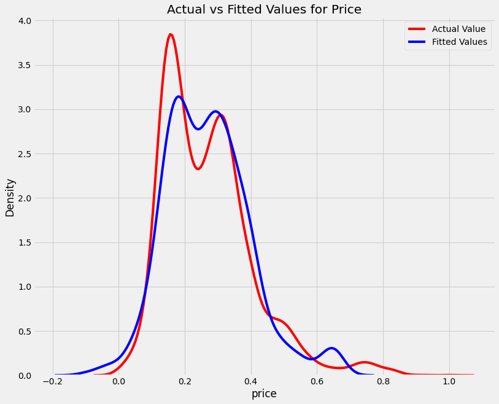

```python
linModel = LinearRegression()
linModel.fit(x_train.values, y_train.values)
y_predLin = linModel.predict(x_test.values)
print("actual value", "            predicted value")
i = 1
while i < 20:
    print(y_test.values[i],"      ",y_predLin[i])
    i += 1

plt.figure(figsize=(12, 10))
ax = sns.distplot(y, hist=False, color="r", label="Actual Value")
sns.distplot(y_predLin, hist=False, color="b", label="Fitted Values" , ax=ax)
plt.title('Actual vs Fitted Values for Price')
plt.legend()
plt.show()
```

```python
mseLin = mean_squared_error(y_test.values, y_predLin)
rmselin = np.sqrt(mean_squared_error(y_test.values, y_predLin))
print('The Mean Squared Error = {0:.4f}'.format(mseLin))
print('Root Mean Squared Error :{0:.4f}'.format(rmselin))
```

```
The Mean Squared Error = 0.0026
Root Mean Squared Error :0.0505
```

```python
r2_Lin = r2_score(y_test.values, y_predLin)
print('Goodness of Fit: {0:.2f}'.format(r2_Lin))
```

```
Goodness of Fit: 0.87
```

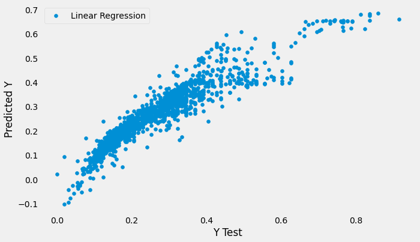

```python
plt.figure(figsize = (10,6))
plt.scatter(y_test, y_predLin, label='Linear Regression')
plt.xlabel('Y Test')
plt.ylabel('Predicted Y')
plt.legend(loc='upper left');
plt.grid()
```

This figure shows predicted and actual prices. As we see, some prices predicted have negative values, which is not possible. In Linear regression some of feature have negative coeefficient values and cause these negative preicted values.

```python
#cross validation
scores = cross_val_score(linModel, x_train, y_train, scoring="neg_mean_squared_error", cv=7)
linModel_rmse_scores = np.sqrt(-scores)

linModel_r2_scores = cross_val_score(linModel, x_train, y_train, scoring="r2", cv=7)



def show_scores(scores, model):
    print("      ",model,"    ")
    print("scores:",scores)
    print("scores_mean :", scores.mean())


show_scores(linModel_rmse_scores,linModel)
print("-"*10)
show_scores(linModel_r2_scores,linModel)
```

```
       LinearRegression()
scores: [4.44449231e-02 1.79290800e+09 4.82397383e-02 2.26668832e+10
 4.80201187e-02 5.07742344e-02 4.40284600e-02]
scores_mean : 3494255888.171599
----------
       LinearRegression()
scores: [ 8.92175209e-01 -2.05100961e+20  8.76011613e-01 -2.73377745e+22
  8.67825460e-01  8.67853878e-01  9.01092071e-01]
scores_mean : -3.934696497436076e+21
```

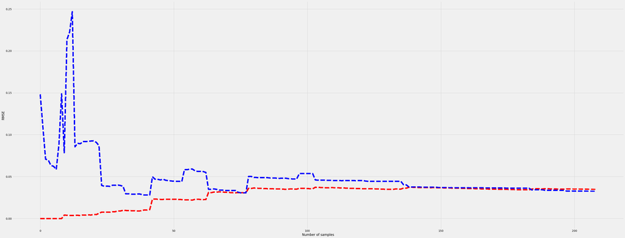

```python
def plot_learning_curves (model, X, y):
    X_train, X_val, y_train, y_val = train_test_split(X, y, test_size=0.3, random_state=42)
    train_errors, val_errors = [], []
    for m in range(1, len(X_train)):
        model.fit(X_train[:m], y_train[:m])
        y_train_pred = model.predict(X_train[:m])
        y_val_pred = model.predict(X_val)
        train_errors.append(mean_squared_error(y_train_pred, y_train[:m]))
        val_errors.append(mean_squared_error(y_val_pred, y_val))
        plt.rcParams["figure.figsize"] = (50, 20)
        plt.plot(np.sqrt(train_errors), 'r--', linewidth=6, label='train')
        plt.plot(np.sqrt(val_errors), 'b--', linewidth=6, label='val')
        plt.ylabel('RMSE')
        plt.xlabel('Number of samples')




plot_learning_curves(linModel, x[:300], y[:300])
```

So, learning curves tell us that the RMSE stabilizes as long as the number of samples grow in volume.

# DecisionTree Model

```
actual value             predicted value
0.23437317443626593         0.22187171398527866
0.06998481130973246         0.10725552050473187
0.415819605094053         0.37466993807687815
0.3726837247341979         0.3692020095805585
0.2754761070218483         0.26103516765977336
0.25236593059936907         0.29884332281808623
0.18226428321065544         0.17053394088094403
0.22895198037153874         0.2522490945203879
0.23016707559294308         0.2523191961677766
0.7195934104451455         0.8364294894263349
0.18226428321065544         0.17455310199789695
0.35494800794485337         0.3714452622969973
0.2983993457179577         0.28694940997780116
0.19850449818904076         0.20551466292791212
0.03502745647856058         0.03960743077462321
0.12379950928846829         0.12379950928846829
0.12641663745764692         0.13155742493281924
0.5069517466993808         0.5326556840752424
0.4392802897534759         0.48592125248276663
```

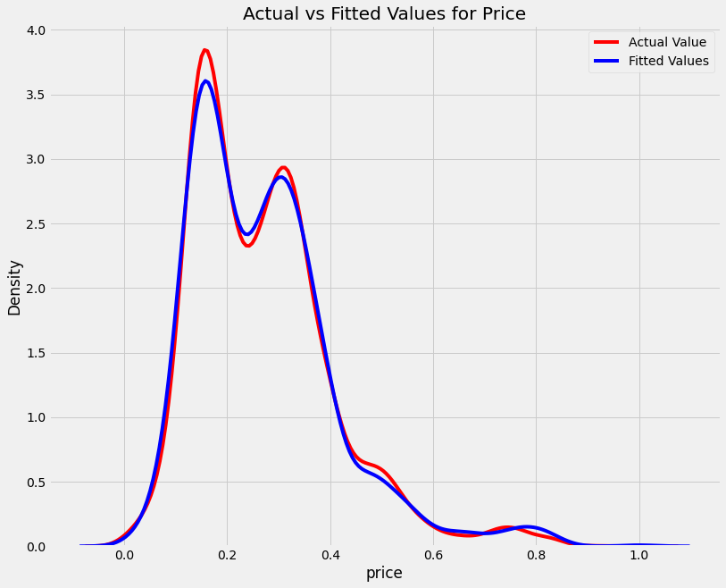

```python
DecisionTree_Model = DecisionTreeRegressor()
DecisionTree_Model.fit(x_train.values, y_train.values)
y_dt_pred = DecisionTree_Model.predict(x_test.values)
print("actual value", "            predicted value")
i = 1
while i < 20:
    print(y_test.values[i],"       ",y_dt_pred[i])
    i += 1

plt.figure(figsize=(12, 10))
ax = sns.distplot(y, hist=False, color="r", label="Actual Value")
sns.distplot(y_dt_pred, hist=False, color="b", label="Fitted Values" , ax=ax)
plt.title('Actual vs Fitted Values for Price')
plt.legend()
plt.show()
```

```python
mse_dt = mean_squared_error(y_test.values, y_dt_pred)
rmse_dt = np.sqrt(mean_squared_error(y_test.values, y_dt_pred))
print('The Mean Squared Error = {0:.4f}'.format(mse_dt))
print('Root Mean Squared Error :{0:.4f}'.format(rmse_dt))
```

```
The Mean Squared Error = 0.0014
Root Mean Squared Error :0.0368
```

```python
r2_dt = r2_score(y_test.values, y_dt_pred)
print('Goodness of Fit: {0:.2f}'.format(r2_dt))
```

```
Goodness of Fit: 0.93
```

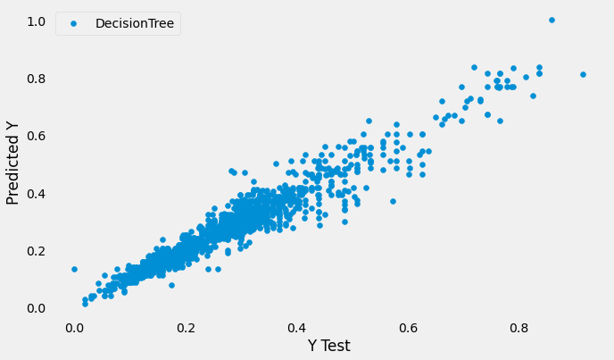

```python
plt.figure(figsize = (10,6))
plt.scatter(y_test, y_dt_pred, label='DecisionTree')
plt.xlabel('Y Test')
plt.ylabel('Predicted Y')
plt.legend(loc='upper left')
plt.legend()
plt.grid()
```

```python
scores = cross_val_score(DecisionTree_Model, x_train, y_train, scoring="neg_mean_squared_error", cv=10)
DecisionTree_rmse_scores = np.sqrt(-scores)

DecisionTree_r2_scores = cross_val_score(DecisionTree_Model, x_train, y_train, scoring="r2", cv=10)



def show_scores(scores, model):
    print("      ",model,"    ")
    print("scores:",scores)
    print("scores_mean", scores.mean())


show_scores(DecisionTree_rmse_scores,DecisionTree_Model)
print("-"*10)
show_scores(DecisionTree_r2_scores,DecisionTree_Model)
```

```
       DecisionTreeRegressor()
scores: [0.03448634 0.03705589 0.04201725 0.03826896 0.03531262 0.03523443
 0.03495813 0.03712369 0.03363404 0.03565915]
scores_mean 0.03637505203859618
----------
       DecisionTreeRegressor()
scores: [0.92959873 0.91954739 0.90204475 0.91987078 0.93179007 0.93084466
 0.93306296 0.93278463 0.93681262 0.93545713]
scores_mean 0.9271813706522553
```

# Random Forest Model

```
actual value predicted value
0.23437317443626593         0.24179577053394102
0.06998481130973246         0.10933239864470147
0.415819605094053         0.38431592475756476
0.3726837247341979         0.3633746933052926
0.2754761070218483         0.26371281691786397
0.25236593059936907         0.3022902208201895
0.18226428321065544         0.1753599719593412
0.22895198037153874         0.23352167309265093
0.23016707559294308         0.2528344432760835
0.7195934104451455         0.761835494800795
0.18226428321065544         0.17928262647505566
0.35494800794485337         0.4206157261362307
0.2983993457179577         0.3181865482727734
0.19850449818904076         0.19443276083654631
0.03502745647856058         0.03760953382404486
0.12379950928846829         0.1312943100829539
0.12641663745764692         0.13071386844257504
0.5069517466993808         0.48528659890174075
0.4392802897534759         0.4442152120574835
```

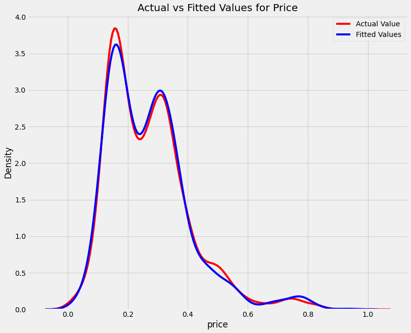

```python
randomForestModel = RandomForestRegressor()
randomForestModel.fit(x_train.values, y_train.values)
y_rf_pred = randomForestModel.predict(x_test.values)
print("actual value", "predicted value")
i = 1
while i < 20:
    print(y_test.values[i],"       ",y_rf_pred[i])
    i += 1
plt.figure(figsize=(12, 10))
ax = sns.distplot(y, hist=False, color="r", label="Actual Value")
sns.distplot(y_rf_pred, hist=False, color="b", label="Fitted Values" , ax=ax)
plt.title('Actual vs Fitted Values for Price')
plt.legend()
plt.show()
```

```python
mse_rf = mean_squared_error(y_test.values, y_rf_pred)
rmse_rf = np.sqrt(mean_squared_error(y_test.values, y_rf_pred))
print('The Mean Squared Error = {0:.4f}'.format(mse_rf))
print('Root Mean Squared Error :{0:.4f}'.format(rmse_rf))
```

```
The Mean Squared Error = 0.0009
Root Mean Squared Error :0.0300
```

```python
r2_rf = r2_score(y_test.values, y_rf_pred)
print('Goodness of Fit: {0:.2f}'.format(r2_rf))
```

```
Goodness of Fit: 0.95
```

```python
scores_randomforrest = cross_val_score(randomForestModel, x_train, y_train, scoring="neg_mean_squared_error", cv=10)
randomForestModel_rmse_scores = np.sqrt(-scores_randomforrest)

randomForestModel_r2_scores = cross_val_score(randomForestModel, x_train, y_train, scoring="r2", cv=10)

def show_scores(scores, model):
    print("      ",model,"    ")
    print("scores:",scores)
    print("scores_mean", scores.mean())


show_scores(randomForestModel_rmse_scores,randomForestModel)
print("-"*10)
show_scores(randomForestModel_r2_scores,randomForestModel)
```

```
       RandomForestRegressor()
scores: [0.03051997 0.02923194 0.03482468 0.0306957  0.0275152  0.02844263
 0.02926808 0.03029258 0.02828441 0.02739067]
scores_mean 0.02964658780208626
----------
       RandomForestRegressor()
scores: [0.94777848 0.94878058 0.93289733 0.94855573 0.9578231  0.95342142
 0.95335814 0.95548759 0.95551445 0.96204986]
scores_mean 0.9515666683785078
```

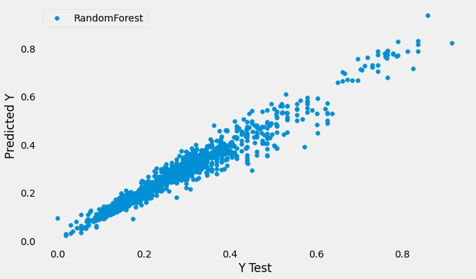

```python
plt.figure(figsize = (10,6))
plt.scatter(y_test, y_rf_pred, label='RandomForest')
plt.xlabel('Y Test')
plt.ylabel('Predicted Y')
plt.legend(loc='upper left');
plt.grid()
```

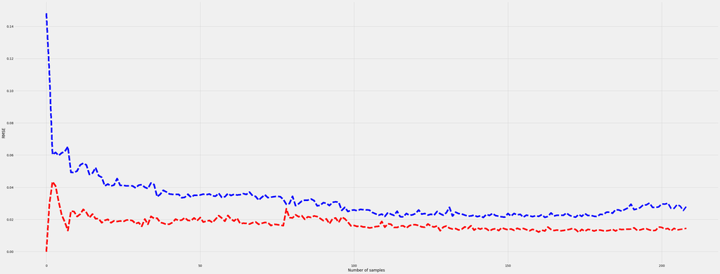

```python
plot_learning_curves(randomForestModel, x[:300], y[:300 ])
```

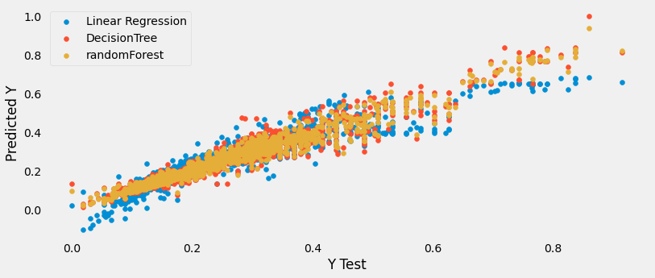

```python
plt.figure(figsize = (12,5))
plt.scatter(y_test, y_predLin, label='Linear Regression')
plt.scatter(y_test, y_dt_pred, label='DecisionTree')
plt.scatter(y_test, y_rf_pred, label='randomForest')
plt.xlabel('Y Test')
plt.ylabel('Predicted Y')
plt.legend(loc='upper left');
plt.grid()
```

**The above plot shows the predicted values of the three models that show Randomforest model predicted values have a great positive corrolation with the actual values and have a less outlier values in comparison with other models result.**